# Assignment 3: Geom Variations in ggplot2

Aliane UMUTESI RegNo:20252MBI054

2026-11-17

## Introduction

The assignment asked to practice a list of `geom_` functions.

The dataset I use is `singer` from the `lattice` package. It has the heights (in inches) of singers from the New York Choral Society, and the column `voice.part` tells us whether someone is Bass, Tenor, Alto or Soprano (1 or 2). That is the same `voice.part` axis we saw on the slide in class.

```r
library(ggplot2)
library(lattice)
data(singer, package = "lattice")

head(singer)
```

```
##   height voice.part
## 1     64  Soprano 1
## 2     62  Soprano 1
## 3     66  Soprano 1
## 4     65  Soprano 1
## 5     60  Soprano 1
## 6     61  Soprano 1
```

```r
str(singer)
```

```
## 'data.frame':    235 obs. of  2 variables:
##  $ height    : num  64 62 66 65 60 61 65 66 65 63 ...
##  $ voice.part: Factor w/ 8 levels "Bass 2","Bass 1",..: 8 8 8 8 8 8 8 8 8 8 ...
```

So we have 235 singers, one numeric variable (`height`) and one categorical variable (`voice.part`). That is a nice mix for trying different geoms.

The basic recipe I keep in mind is:

`ggplot(data, aes(x, y)) + geom_something()`

## 1. geom_bar(): how many in each group?

`geom_bar()` counts the rows for me, so I only give it an x variable.

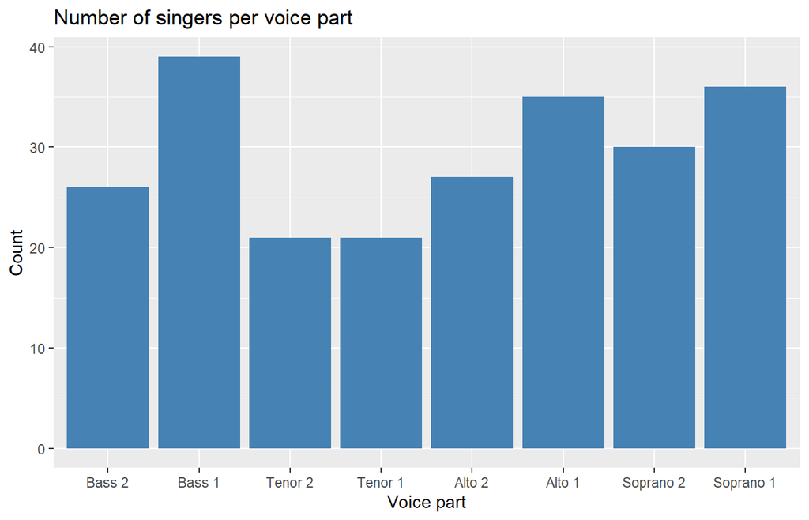

```r
ggplot(singer, aes(x = voice.part)) +
  geom_bar(fill = "steelblue") +
  labs(title = "Number of singers per voice part", x = "Voice part", y = "Count")
```

## 2. geom_histogram(): the shape of one numeric variable

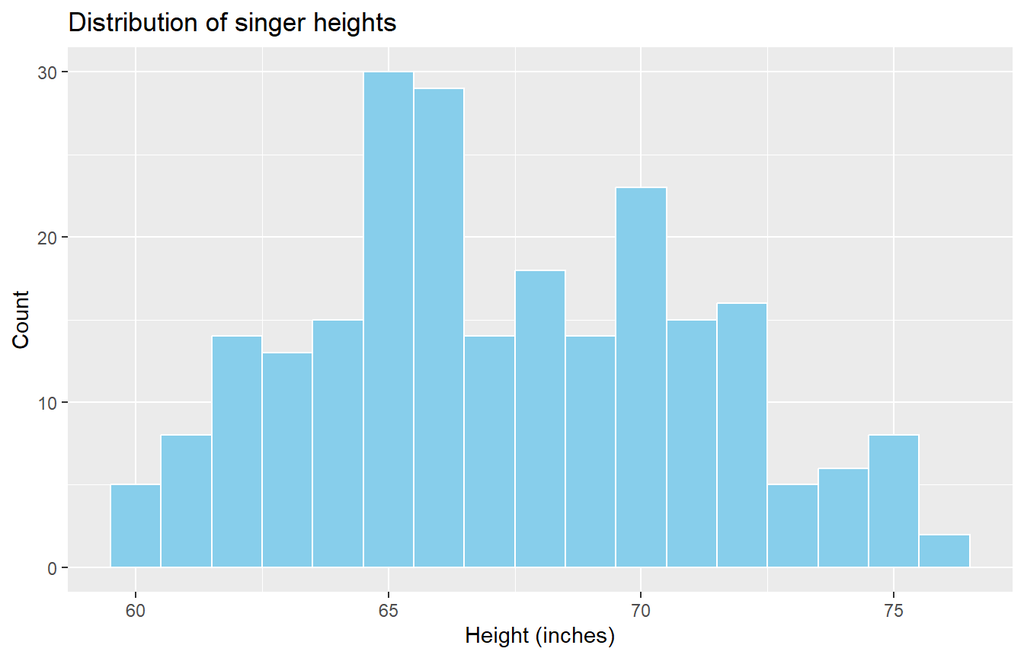

```r
ggplot(singer, aes(x = height)) +
  geom_histogram(binwidth = 1, fill = "skyblue", color = "white") +
  labs(title = "Distribution of singer heights", x = "Height (inches)", y = "Count")
```

**What I notice:** most people sit in the middle and fewer are very short or very tall, which gives a rough bell shape. The `binwidth` matters. If I make it too big the shape disappears, and if I make it too small the plot looks noisy.

## 3. geom_density(): a smooth version of the histogram

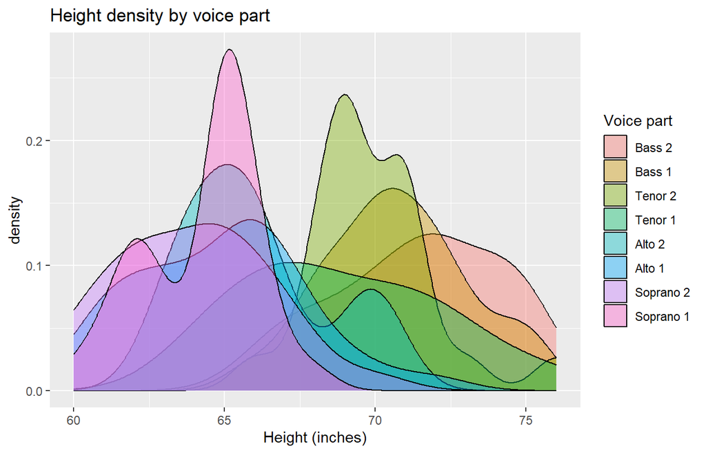

```r
ggplot(singer, aes(x = height, fill = voice.part)) +
  geom_density(alpha = 0.4) +
  labs(title = "Height density by voice part", x = "Height (inches)", fill = "Voice part")
```

**What I notice:** the curves for Bass and Tenor sit further to the right (taller people) and Soprano and Alto sit further to the left. The `alpha = 0.4` makes the fill see-through so overlapping curves can still be read.

## 4. geom_rug(): small ticks for the real data points

A rug adds little tick marks on the axis, one for each observation. I like pairing it with a density curve so the smooth line is not hiding the raw data.

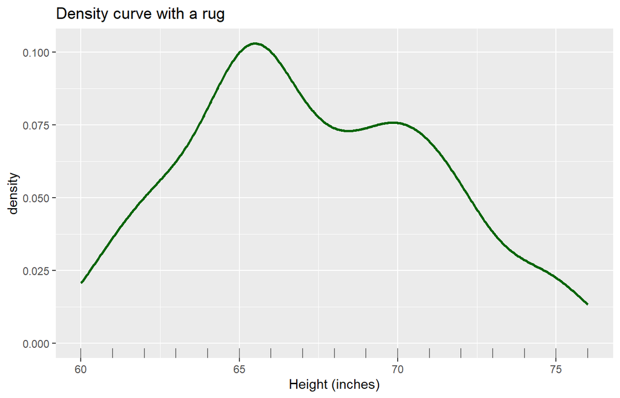

```r
ggplot(singer, aes(x = height)) +
  geom_density(color = "darkgreen", linewidth = 1) +
  geom_rug(alpha = 0.5) +
  labs(title = "Density curve with a rug", x = "Height (inches)")
```

**What I notice:** where the ticks are packed together, the density curve is high. It is a simple way to show where the data really is.

## 5. geom_boxplot(): compare groups and spot outliers

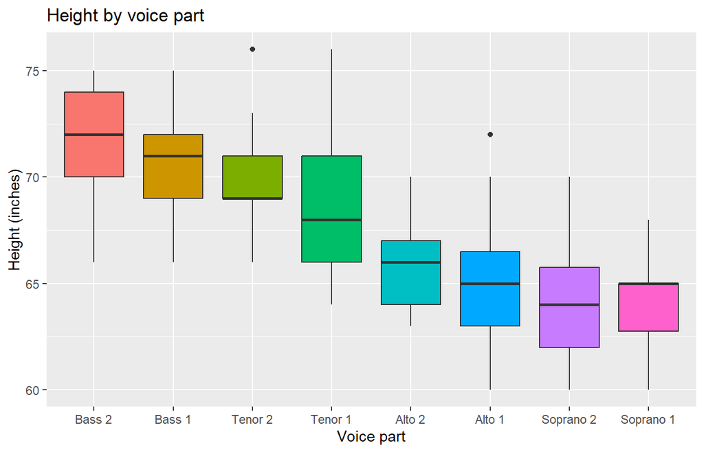

```r
ggplot(singer, aes(x = voice.part, y = height, fill = voice.part)) +
  geom_boxplot(show.legend = FALSE) +
  labs(title = "Height by voice part", x = "Voice part", y = "Height (inches)")
```

**What I notice:** the Bass and Tenor boxes are clearly higher than the Alto and Soprano boxes. That makes sense, since the lower voice parts are mostly men, who on average are taller.

## 6. geom_violin(): a boxplot that also shows the shape

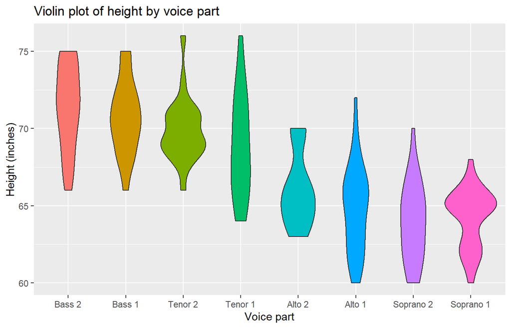

```r
ggplot(singer, aes(x = voice.part, y = height, fill = voice.part)) +
  geom_violin(show.legend = FALSE) +
  labs(title = "Violin plot of height by voice part", x = "Voice part", y = "Height (inches)")
```

**What I notice:** the width of each violin shows where most of the data is. It tells me more than a boxplot, for example if a group had two peaks, a boxplot would hide that.

## 7. geom_jitter(): show every point without overlap

Many singers have the same height, so plain points would sit on top of each other. `geom_jitter()` moves them slightly sideways so I can see them all.

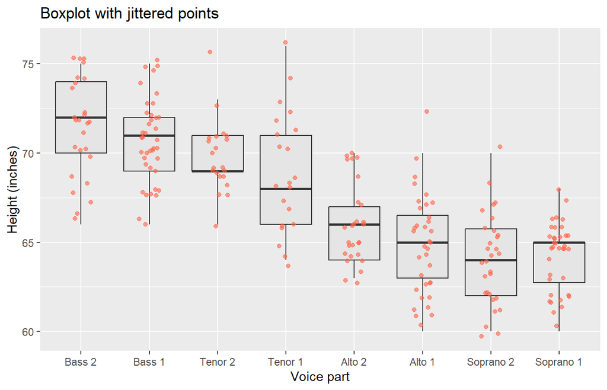

```r
ggplot(singer, aes(x = voice.part, y = height)) +
  geom_boxplot(outlier.shape = NA, fill = "grey90") +
  geom_jitter(width = 0.15, alpha = 0.6, color = "tomato") +
  labs(title = "Boxplot with jittered points", x = "Voice part", y = "Height (inches)")
```

**What I notice:** layering the raw points over the boxplot gives me both the summary and the real data. I set `outlier.shape = NA` so the outliers are not drawn twice.

## 8. geom_hline() and geom_vline(): reference lines

These draw a fixed horizontal or vertical line, which is useful for marking an average.

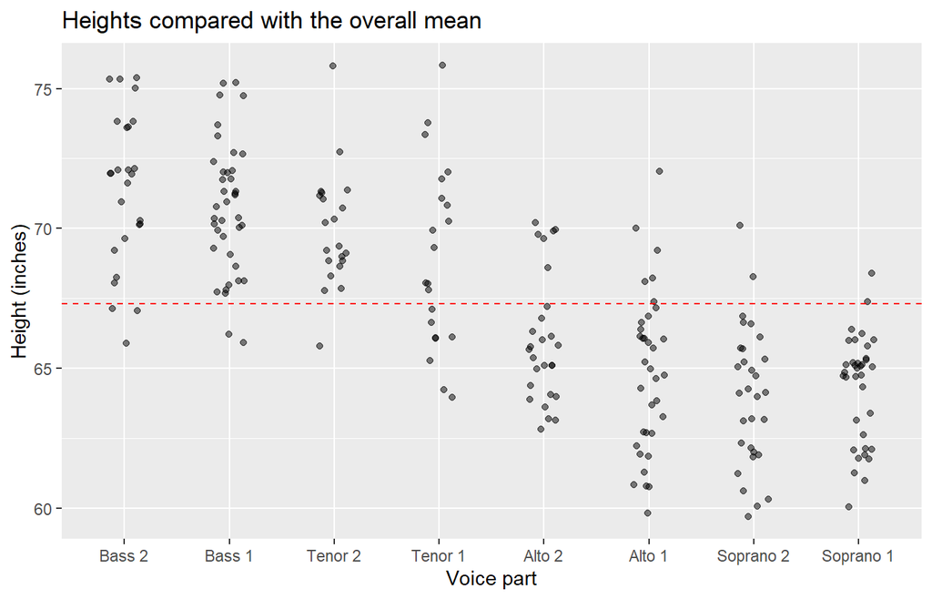

```r
ggplot(singer, aes(x = voice.part, y = height)) +
  geom_jitter(width = 0.15, alpha = 0.5) +
  geom_hline(yintercept = mean(singer$height), linetype = "dashed", color = "red") +
  labs(title = "Heights compared with the overall mean", x = "Voice part", y = "Height (inches)")
```

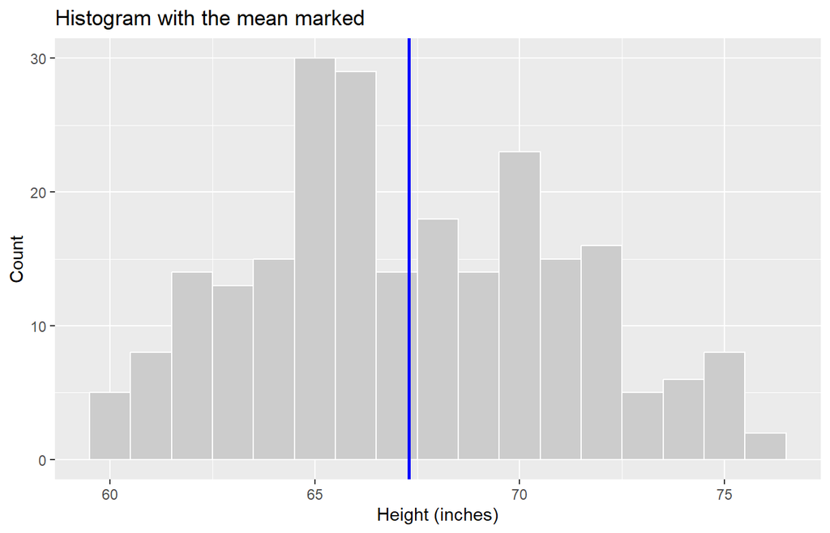

```r
ggplot(singer, aes(x = height)) +
  geom_histogram(binwidth = 1, fill = "grey80", color = "white") +
  geom_vline(xintercept = mean(singer$height), color = "blue", linewidth = 1) +
  labs(title = "Histogram with the mean marked", x = "Height (inches)", y = "Count")
```

**What I notice:** `geom_hline()` uses `yintercept` and `geom_vline()` uses `xintercept`. At first I kept mixing these up.

## 9. geom_line(): connect values in order

A line plot is normally used for time, but I can also use it to connect the group averages. First I calculate the mean height for each voice part.

```r
avg <- aggregate(height ~ voice.part, data = singer, FUN = mean)
avg$height <- round(avg$height, 1)
avg
```

```
##   voice.part height
## 1     Bass 2   71.4
## 2     Bass 1   70.7
## 3    Tenor 2   69.9
## 4    Tenor 1   68.9
## 5     Alto 2   66.0
## 6     Alto 1   64.9
## 7  Soprano 2   64.0
## 8  Soprano 1   64.2
```

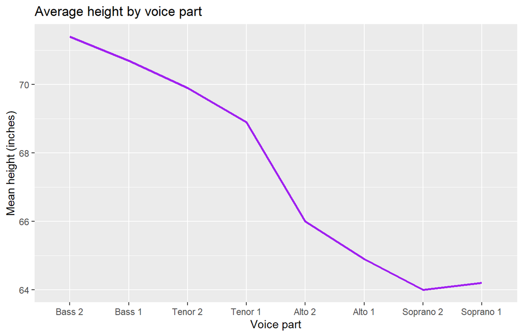

```r
ggplot(avg, aes(x = voice.part, y = height, group = 1)) +
  geom_line(color = "purple", linewidth = 1) +
  labs(title = "Average height by voice part", x = "Voice part", y = "Mean height (inches)")
```

**What I notice:** I needed `group = 1`, otherwise ggplot does not know the categories belong to one line. The line falls from Bass 2 to Soprano 1, which matches what the boxplot showed. One honest caveat is that the voice parts are categories, not numbers, so the line is only a visual aid.

## 10. geom_text(): write labels on the plot

Using the average table from above, I can print the value next to each point.

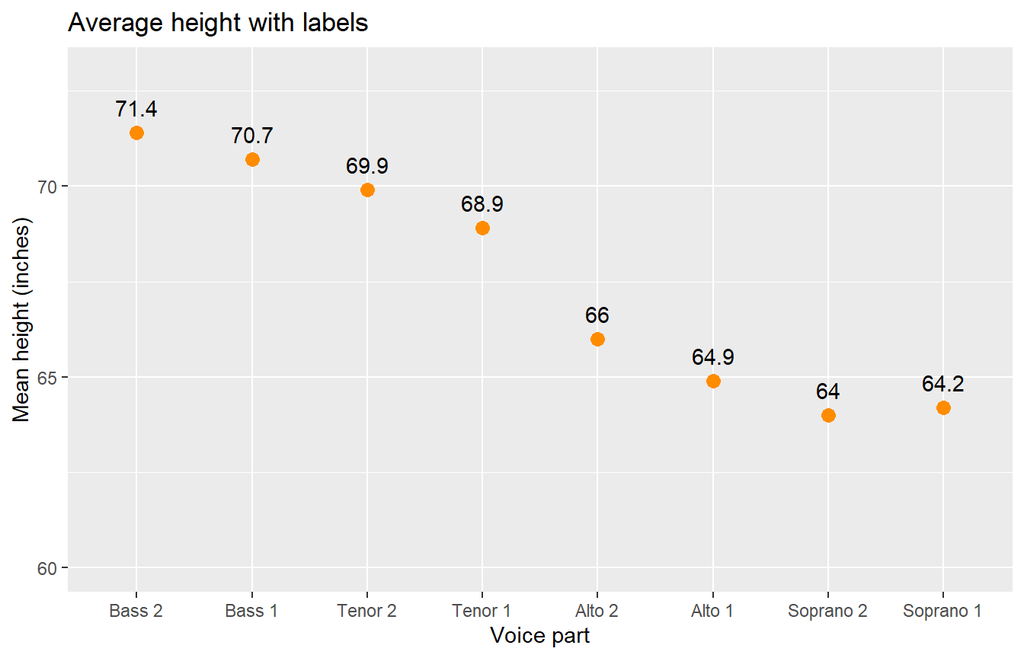

```r
ggplot(avg, aes(x = voice.part, y = height, label = height)) +
  geom_point(size = 3, color = "darkorange") +
  geom_text(vjust = -1) +
  ylim(60, 73) +
  labs(title = "Average height with labels", x = "Voice part", y = "Mean height (inches)")
```

**What I notice:** the `label` aesthetic tells `geom_text()` what to print. `vjust = -1` lifts the text above the point so they do not overlap.

## 11. Bonus: geom_point() and geom_smooth()

These two were commented out on the slide, but I tried them anyway since they are the most common geoms.

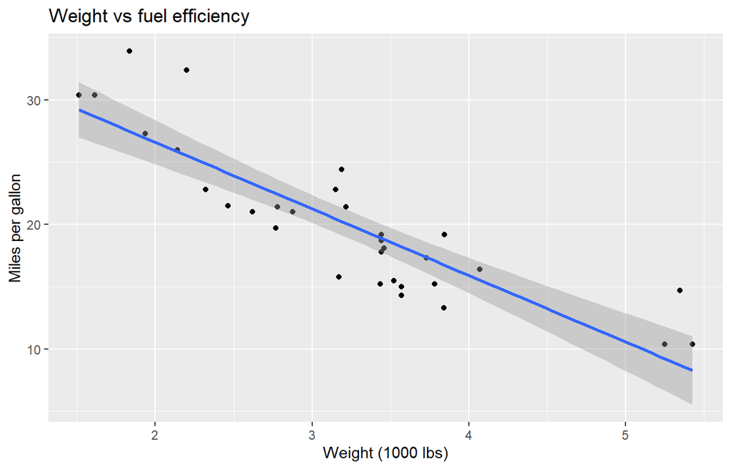

```r
ggplot(mtcars, aes(x = wt, y = mpg)) +
  geom_point() +
  geom_smooth(method = "lm", se = TRUE) +
  labs(title = "Weight vs fuel efficiency", x = "Weight (1000 lbs)", y = "Miles per gallon")
```

**What I notice:** heavier cars have lower mpg. `geom_smooth(method = "lm")` draws a straight regression line, which connects nicely to my linear regression assignment.

## Summary

| Geom | When I would use it |
| --- | --- |
| `geom_bar` | Counting how many rows fall in each category |
| `geom_histogram` | Shape of one numeric variable |
| `geom_density` | Smooth version of the histogram, good for comparing groups |
| `geom_rug` | Showing the real data points along an axis |
| `geom_boxplot` | Comparing groups, spotting outliers |
| `geom_violin` | Comparing groups and seeing their shape |
| `geom_jitter` | Showing all points when many overlap |
| `geom_hline` / `geom_vline` | Marking a mean or a threshold |
| `geom_line` | Connecting ordered values, like time |
| `geom_text` | Writing values or names on the plot |

## What I learned

The biggest lesson for me is that the same data looks different with each geom, and each one answers a different question. For one numeric variable I now reach for a histogram or density, for comparing groups a boxplot or violin, and when I want the real points I add `geom_jitter()` on top. I also learned that layers are added with `+`, and that things I want to change by data go inside `aes()` while fixed styling goes outside it.